# Potentially inappropriate prescribing of DOACs to people with mechanical heart valves: a federated analysis of 57.9 million patients’ primary care records in situ using OpenSAFELY

National guidance was issued during the COVID-19 pandemic to switch patients on warfarin to direct oral anticoagulants (DOACs) where appropriate as these require less frequent blood testing(1). DOACs are not recommended for patients with mechanical heart valves. We conducted a retrospective cohort study of DOAC prescribing in people with a record of a mechanical heart valve between January 2019 and December 2021 and describe the characteristics of this population. For a full description of the study methods and discussion of the study results please see our [published article](https://linkinghub.elsevier.com/retrieve/pii/S0049384822000305).

We identified 16,727 individuals with a mechanical heart valve recorded in their records, of whom 1,149 (6.9%) had been prescribed a DOAC during the study period. 664 individuals with a record of a mechanical heart valve were currently prescribed (within the previous 3 months) a DOAC as of December 31st 2021. This is suggestive of inappropriate prescribing of DOACs in individuals with mechanical heart valves. Direct alerts have been issued to clinicians through their EHR software informing the issue. Following an earlier version of this analysis NHS England issued a National Patient Safety Alert highlighting that clinicians should review affected patients(2). We show that the OpenSAFELY platform can be used for rapid audit and feedback to mitigate the indirect health impacts of COVID-19 on the NHS. We will monitor changes in prescribing for this risk group over the following months.

## Results

### Monthly Count

The monthly number of DOAC prescriptions in people with a record of a mechanical valve.

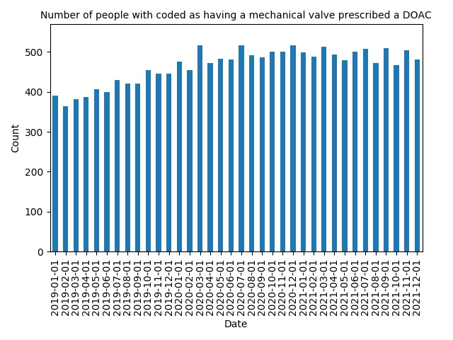

**Figure 1. The monthly number of people with a record of a mechanical valve who are also prescribed a DOAC between January 2019 and December 2021.**

In the six months following national anticoagulation switching guidance, we observed a mean number of 493 (95% C.I = 475, 511), compared to a mean of 449 (95% C.I = 432, 466) in the six months prior. The highest rate of 38.6 per 1000 patients coded as having a mechanical valve prescribed DOACs was observed in March 2020, the month the guidance was issued. The rate then plateaued, with a mean number of patients recorded as having a mechanical valve receiving a DOAC between January 2021 and July 2021, the month the National Patient Safety Alert was issued, of 495 (95% C.I = 477, 513). This remained similar in the last 5 months since issuing of a national safety alert in July 2021, with a mean count of 486 (95% C.I = 467, 505).

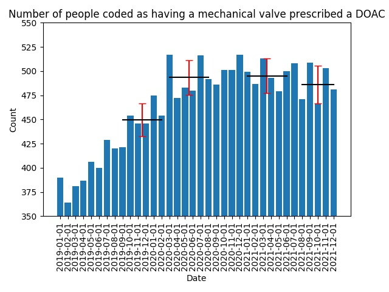

**Figure 2. The monthly number of people with a record of a mechanical valve who are also prescribed a DOAC between January 2019 and December 2021 with the mean value 6 months prior to and 6 months after the issuing of national anticoagulation switching guidance as well as 6 months prior to and 5 months following the issuing of a national patient safety alert.**

### Monthly Rate

The monthly rate of DOAC prescribing per 1000 people with a record of a mechanical valve.

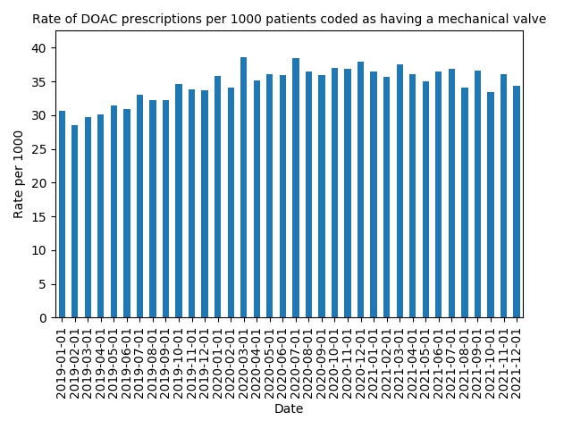

**Figure 3. The monthly rate of people prescribed a DOAC per 1000 people with a record of a mechanical heart valve between January 2019 and December 2021.**

### References

1. Clinical guide for the management of anticoagulant services during the coronavirus pandemic [Internet]. NHS England. [cited 2021 Sep 30]. Available from: https://www.nice.org.uk/Media/Default/About/COVID-19/Specialty-guides/specialty-guide-anticoagulant-services-and-coronavirus.pdf
2. Inappropriate anticoagulation of patients with a mechanical heart valve [Internet]. NHS England. Available from: https://www.england.nhs.uk/2021/07/inappropriate-anticoagulation-of-patients-with-a-mechanical-heart-valve/